# AS4

Zhilin Yang

2023-07-15

```r
# Load the required packages
library(readxl)
```

```r
library(ggplot2)
library(fpp)
library(TSA)
library(forecast)
```

## Question 1:

Combine the data from the 16 files into a single dataset and plot it. Describe the dataset characteristics.

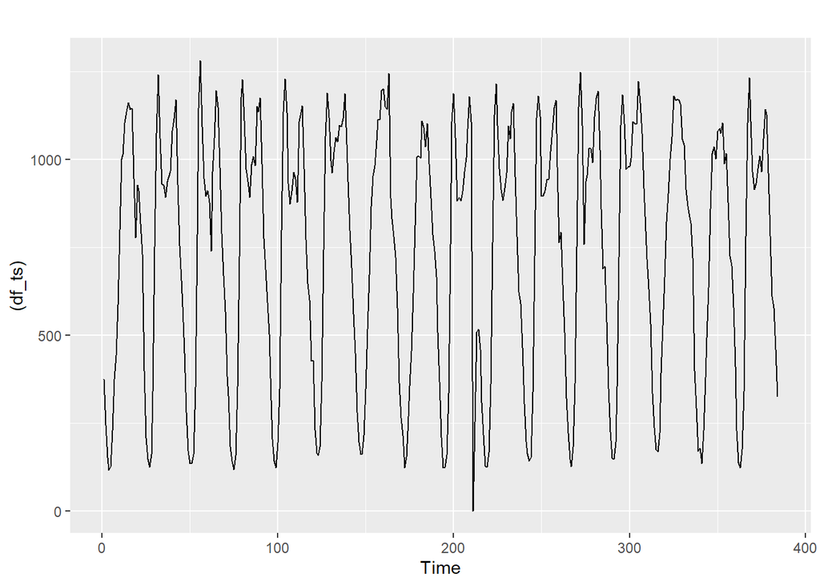

```r
combined_data = read.csv("C:/Users/Richa/Desktop/TS/week4/Combined_data.csv")
df_ts = ts(combined_data$Value, frequency = 1)
autoplot((df_ts))
```

## Question 2:

Split the dataset into a training dataset which includes 6/16/2013 - 6/30/2013 samples and a test dataset which includes 7/1/2013 samples and plot the ACF and PACF.

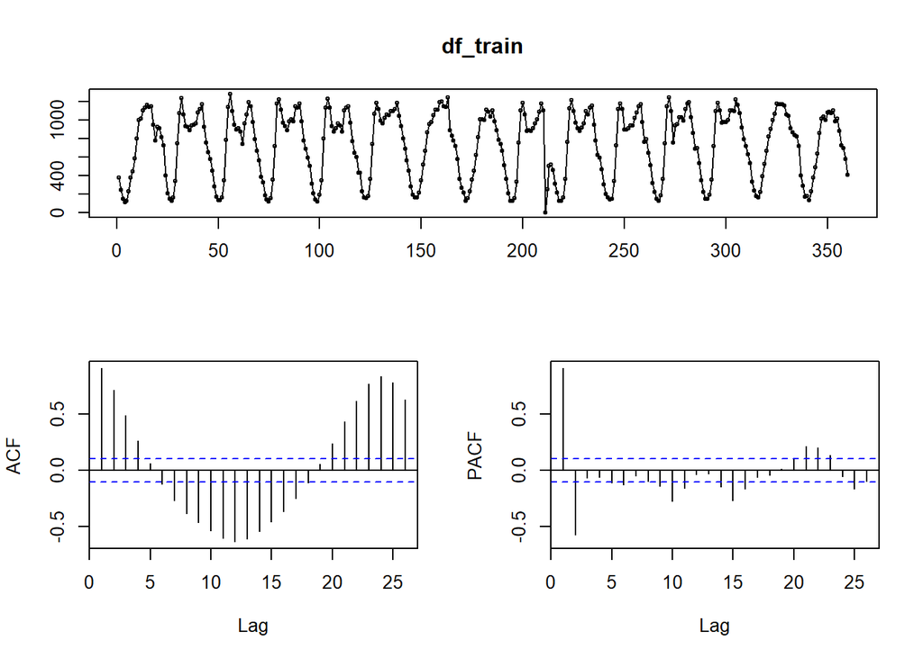

```r
# Split the data into train and test
df_train <- window(df_ts, start = 1, end = 360)
df_test <- window(df_ts, start = 361,end = 384)

# Plot ACF and PACF for the training dataset
tsdisplay(df_train)
```

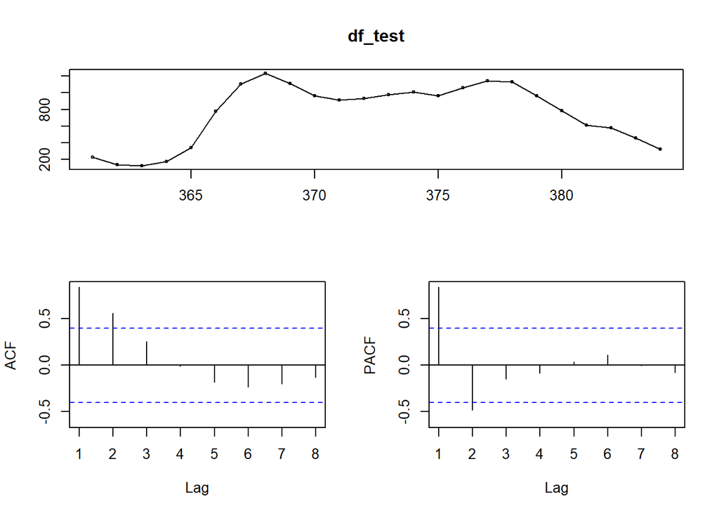

```r
# Plot ACF and PACF for the testing dataset
tsdisplay(df_test)
```

## Question 3:

Build an 𝐴𝑅𝐼𝑀𝐴(𝑝, 𝑑, 𝑞) model using the training dataset and R auto.arima() function. Change the values of 𝑝 and 𝑞 and determine the best model using AICc and BIC values. Do AICc and BIC select the same model as the best model? For each derived model, review the residual plots for the residuals ACF and normality.

```r
#Auto Arima
auto_ar_fit = auto.arima(df_train, trace = TRUE)
```

```
##
##  Fitting models using approximations to speed things up...
##
##  ARIMA(2,0,2) with non-zero mean : 4451.597
##  ARIMA(0,0,0) with non-zero mean : 5263.162
##  ARIMA(1,0,0) with non-zero mean : 4647.105
##  ARIMA(0,0,1) with non-zero mean : 4888.443
##  ARIMA(0,0,0) with zero mean     : 5858.997
##  ARIMA(1,0,2) with non-zero mean : 4516.808
##  ARIMA(2,0,1) with non-zero mean : 4495.758
##  ARIMA(3,0,2) with non-zero mean : 4453.461
##  ARIMA(2,0,3) with non-zero mean : 4450.838
##  ARIMA(1,0,3) with non-zero mean : 4510.357
##  ARIMA(3,0,3) with non-zero mean : 4453.807
##  ARIMA(2,0,4) with non-zero mean : 4450.888
##  ARIMA(1,0,4) with non-zero mean : 4512.163
##  ARIMA(3,0,4) with non-zero mean : 4455.568
##  ARIMA(2,0,3) with zero mean     : 4546.084
##
##  Now re-fitting the best model(s) without approximations...
##
##  ARIMA(2,0,3) with non-zero mean : 4455.881
##
##  Best model: ARIMA(2,0,3) with non-zero mean
```

```r
auto_ar_fit
```

```
## Series: df_train
## ARIMA(2,0,3) with non-zero mean
##
## Coefficients:
##          ar1      ar2      ma1      ma2      ma3      mean
##       1.8088  -0.8853  -0.5348  -0.2671  -0.1157  746.3181
## s.e.  0.0288   0.0287   0.0600   0.0596   0.0654    6.8586
##
## sigma^2 = 13443:  log likelihood = -2220.78
## AIC=4455.56   AICc=4455.88   BIC=4482.77
```

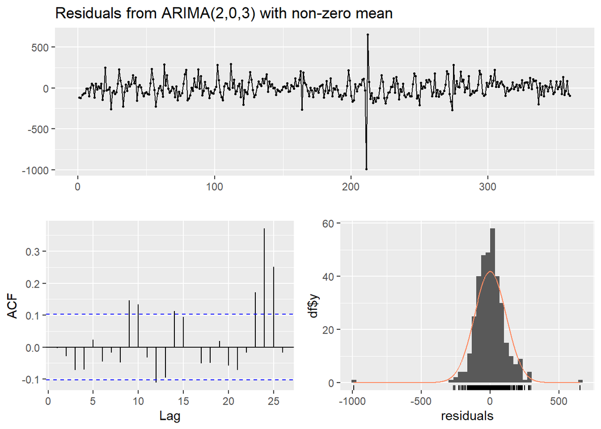

```
##
##  Ljung-Box test
##
## data:  Residuals from ARIMA(2,0,3) with non-zero mean
## Q* = 20.439, df = 5, p-value = 0.001033
##
## Model df: 5.   Total lags used: 10
```

```r
# residuals
checkresiduals(auto_ar_fit)
```

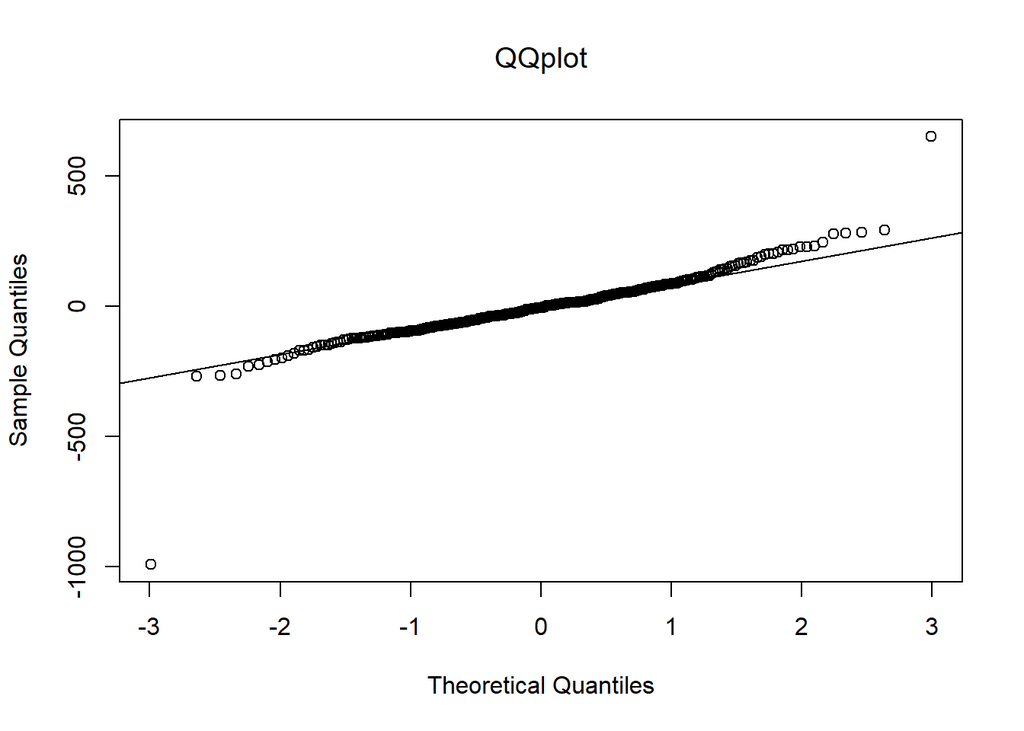

```r
# normality
qqnorm(auto_ar_fit$residuals,main=expression(QQplot))
qqline(auto_ar_fit$residuals)
```

The best model selected by auto arima is ARIMA(2,0,3) with AIC = 4455.56 and BIC=4482.77

Now check for other models

#### Arima (2,0,1)

```r
fit1 = Arima(df_train, order = c(2,0,1))
fit1
```

```
## Series: df_train
## ARIMA(2,0,1) with non-zero mean
##
## Coefficients:
##          ar1      ar2      ma1      mean
##       1.5254  -0.6671  -0.1343  740.0717
## s.e.  0.0776   0.0714   0.1109   39.4450
##
## sigma^2 = 15282:  log likelihood = -2244.29
## AIC=4498.59   AICc=4498.76   BIC=4518.02
```

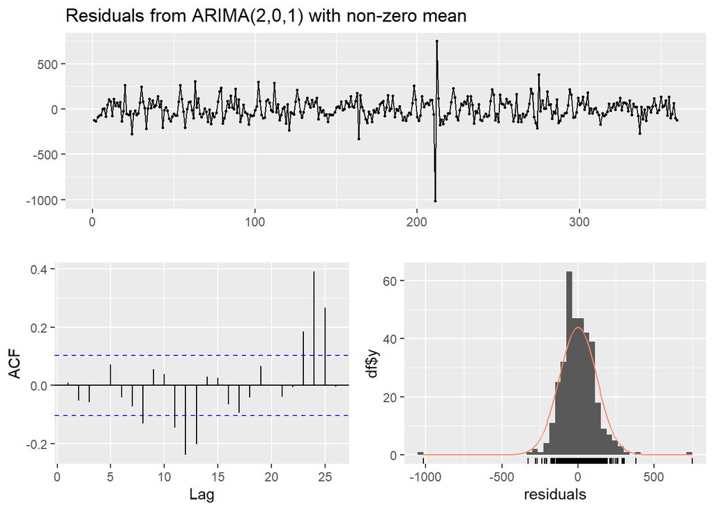

```
##
##  Ljung-Box test
##
## data:  Residuals from ARIMA(2,0,1) with non-zero mean
## Q* = 14.715, df = 7, p-value = 0.03983
##
## Model df: 3.   Total lags used: 10
```

```r
# residuals
checkresiduals(fit1)
```

#### Arima (2,0,2)

```r
fit2 = Arima(df_train, order = c(2,0,2))
fit2
```

```
## Series: df_train
## ARIMA(2,0,2) with non-zero mean
##
## Coefficients:
##          ar1      ar2      ma1      ma2      mean
##       1.8308  -0.9072  -0.5916  -0.3254  746.3649
## s.e.  0.0229   0.0228   0.0488   0.0471    6.9120
##
## sigma^2 = 13514:  log likelihood = -2222.26
## AIC=4456.52   AICc=4456.76   BIC=4479.83
```

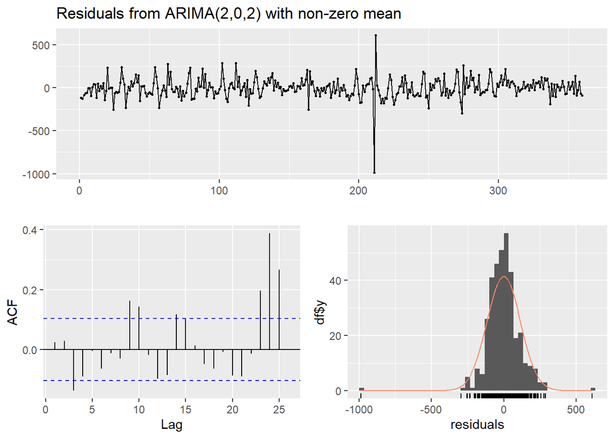

```
##
##  Ljung-Box test
##
## data:  Residuals from ARIMA(2,0,2) with non-zero mean
## Q* = 29.589, df = 6, p-value = 4.704e-05
##
## Model df: 4.   Total lags used: 10
```

```r
# residuals
checkresiduals(fit2)
```

#### Arima (3,0,4)

```r
fit3 = Arima(df_train, order = c(3,0,4))
fit3
```

```
## Series: df_train
## ARIMA(3,0,4) with non-zero mean
##
## Coefficients:
##          ar1     ar2      ar3     ma1      ma2      ma3      ma4      mean
##       0.8322  0.8770  -0.8602  0.4582  -0.7875  -0.3765  -0.1307  746.3061
## s.e.  0.0314  0.0269   0.0319  0.0618   0.0688   0.0606   0.0658    6.8538
##
## sigma^2 = 13340:  log likelihood = -2219.25
## AIC=4456.5   AICc=4457.01   BIC=4491.47
```

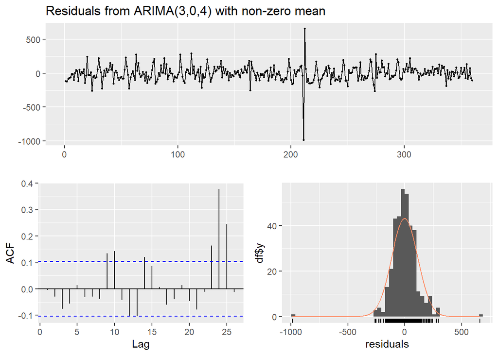

```
##
##  Ljung-Box test
##
## data:  Residuals from ARIMA(3,0,4) with non-zero mean
## Q* = 19.056, df = 3, p-value = 0.0002662
##
## Model df: 7.   Total lags used: 10
```

```r
# residuals
checkresiduals(fit3)
```

#### Arima (1,0,3)

```r
fit4 = Arima(df_train, order = c(1,0,3))
fit4
```

```
## Series: df_train
## ARIMA(1,0,3) with non-zero mean
##
## Coefficients:
##          ar1     ma1     ma2     ma3      mean
##       0.7131  0.7151  0.4540  0.1921  735.2137
## s.e.  0.0529  0.0686  0.0782  0.0644   53.5992
##
## sigma^2 = 15765:  log likelihood = -2249.36
## AIC=4510.72   AICc=4510.96   BIC=4534.03
```

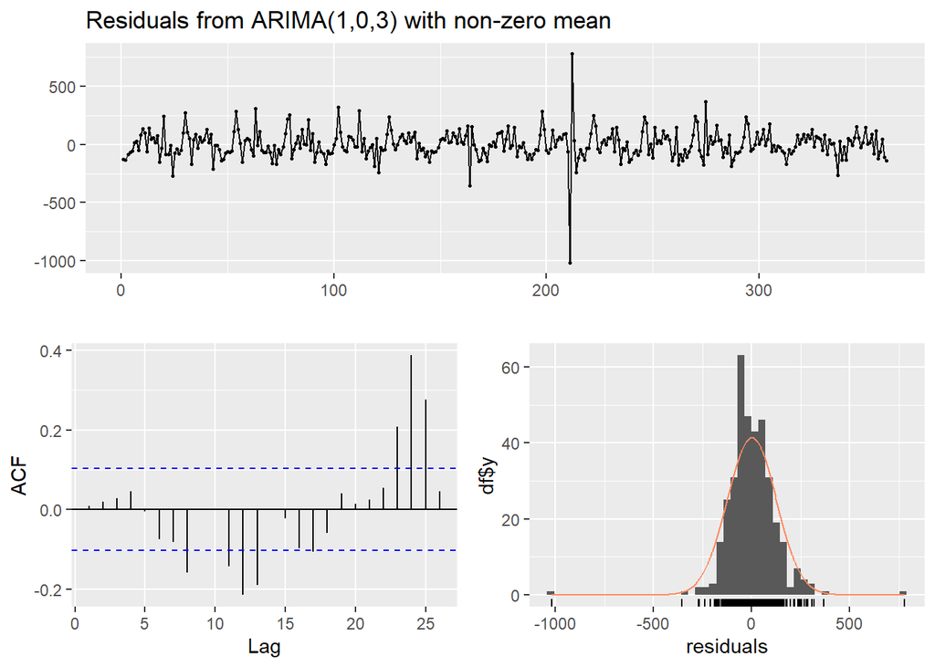

```
##
##  Ljung-Box test
##
## data:  Residuals from ARIMA(1,0,3) with non-zero mean
## Q* = 15.073, df = 6, p-value = 0.01969
##
## Model df: 4.   Total lags used: 10
```

```r
# residuals
checkresiduals(fit4)
```

## Question 4:

Build a day of the week seasonal 𝐴𝑅𝐼𝑀𝐴(𝑝, 𝑑, 𝑞)(𝑃,𝑄,𝐷)𝑠 model using the training dataset and R auto.arima() function.

```r
df_week = ts(df_train,frequency=168)
df_weekfit = auto.arima(df_week,seasonal = TRUE, trace = TRUE)
```

```
##
##  Fitting models using approximations to speed things up...
##
##  ARIMA(2,1,2)(0,1,0)[168]                    : 708.6878
##  ARIMA(0,1,0)(0,1,0)[168]                    : 753.3879
##  ARIMA(1,1,0)(0,1,0)[168]                    : 751.2625
##  ARIMA(0,1,1)(0,1,0)[168]                    : 741.6902
##  ARIMA(1,1,2)(0,1,0)[168]                    : 701.9879
##  ARIMA(0,1,2)(0,1,0)[168]                    : 697.6038
##  ARIMA(0,1,3)(0,1,0)[168]                    : Inf
##  ARIMA(1,1,1)(0,1,0)[168]                    : 706.6805
##  ARIMA(1,1,3)(0,1,0)[168]                    : 703.5227
##
##  Now re-fitting the best model(s) without approximations...
##
##  ARIMA(0,1,2)(0,1,0)[168]                    : 2249.441
##
##  Best model: ARIMA(0,1,2)(0,1,0)[168]
```

```r
df_weekfit
```

```
## Series: df_week
## ARIMA(0,1,2)(0,1,0)[168]
##
## Coefficients:
##           ma1      ma2
##       -0.4741  -0.4853
## s.e.   0.0593   0.0586
##
## sigma^2 = 7081:  log likelihood = -1121.66
## AIC=2249.31   AICc=2249.44   BIC=2259.07
```

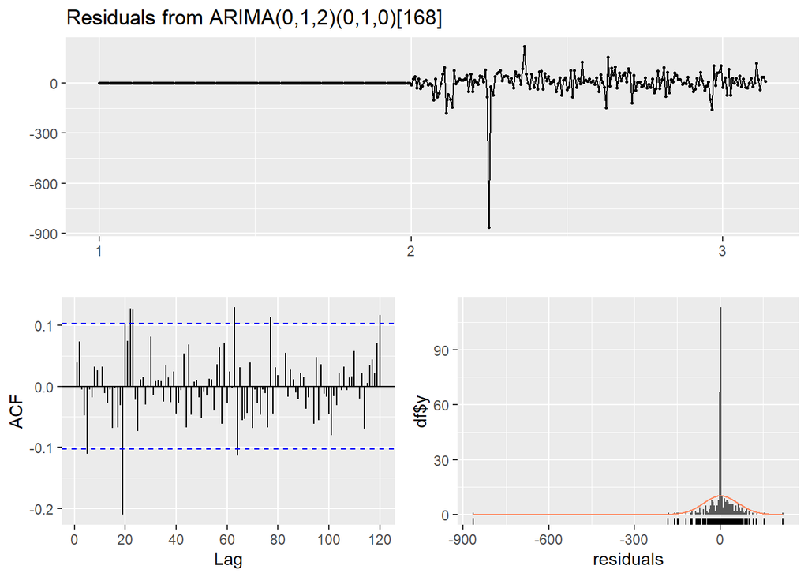

```
##
##  Ljung-Box test
##
## data:  Residuals from ARIMA(0,1,2)(0,1,0)[168]
## Q* = 91.812, df = 70, p-value = 0.04131
##
## Model df: 2.   Total lags used: 72
```

```r
checkresiduals(df_weekfit)
```

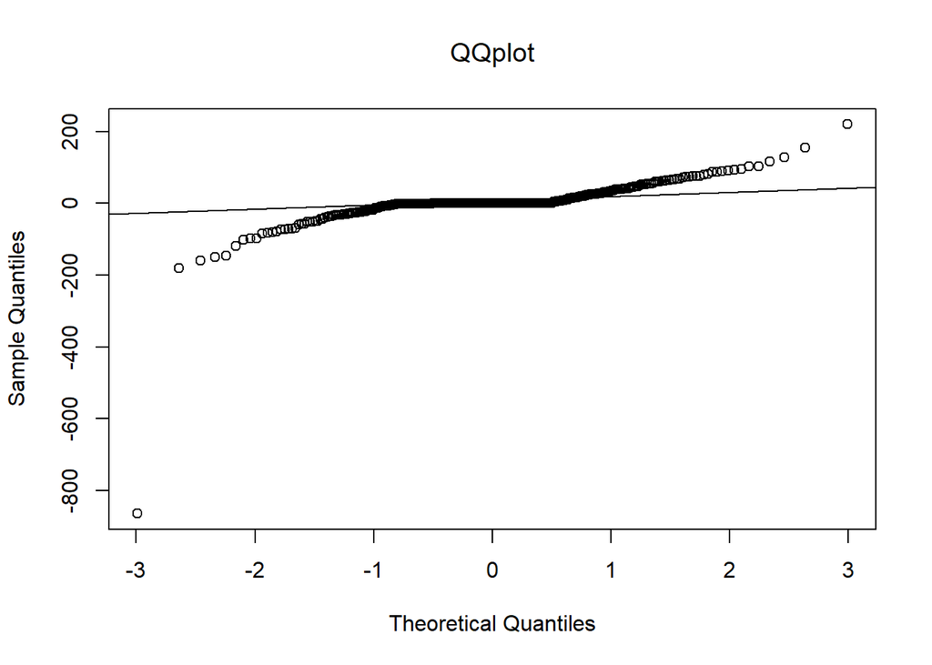

```r
qqnorm(df_weekfit$residuals,main=expression(QQplot))
qqline(df_weekfit$residuals)
```

We can see that the AIC =2249.31 for the day of week model

## Question 5:

Use the 𝐴𝑅𝐼𝑀𝐴(𝑝, 𝑑, 𝑞)(𝑃, 𝑄, 𝐷)𝑠 model from Question 4 to forecast for July 1st (which is a Monday). Plot your result.

```r
July1_predicted_week <- forecast((df_weekfit), h = 24)
July1_predicted_week
```

```
##          Point Forecast      Lo 80     Hi 80       Lo 95     Hi 95
## 3.142857      231.35419  123.51099  339.1974   66.422255  396.2861
## 3.148810      140.97855   19.13187  262.8252  -45.369876  327.3270
## 3.154762      141.97855   20.05314  263.9040  -44.490283  328.4474
## 3.160714      176.97855   54.97446  298.9827   -9.610612  363.5677
## 3.166667      352.97855  230.89583  475.0613  166.269136  539.6880
## 3.172619      775.97855  653.81725  898.1399  589.148962  962.8081
## 3.178571     1125.97855 1003.73872 1248.2184  939.028865 1312.9282
## 3.184524     1205.97855 1083.66025 1328.2969 1018.908845 1393.0483
## 3.190476     1080.97855  958.58182 1203.3753  893.788902 1268.1682
## 3.196429      899.97855  777.50344 1022.4537  712.669036 1087.2881
## 3.202381      909.97855  787.42512 1032.5320  722.549246 1097.4079
## 3.208333      898.97855  776.34684 1021.6103  711.429533 1086.5276
## 3.214286      926.97855  804.26862 1049.6885  739.309897 1114.6472
## 3.220238      982.97855  860.19044 1105.7667  795.190336 1170.7668
## 3.226190     1022.97855  900.11231 1145.8448  835.070852 1210.8863
## 3.232143     1104.97855  982.03424 1227.9229  916.951443 1293.0057
## 3.238095     1196.97855 1073.95621 1320.0009 1008.832111 1385.1250
## 3.244048     1125.97855 1002.87823 1249.0789  937.712854 1314.2443
## 3.250000       17.97855 -105.19970  141.1568 -170.406328  206.3634
## 3.255952      270.97855  147.72242  394.2347   82.474566  459.4825
## 3.261905      525.97855  402.64459  649.3125  337.355535  714.6016
## 3.267857      534.97855  411.56681  658.3903  346.236579  723.7205
## 3.273810      476.97855  353.48908  600.4680  288.117698  665.8394
## 3.279762      326.97855  203.41140  450.5457  137.998892  515.9582
```

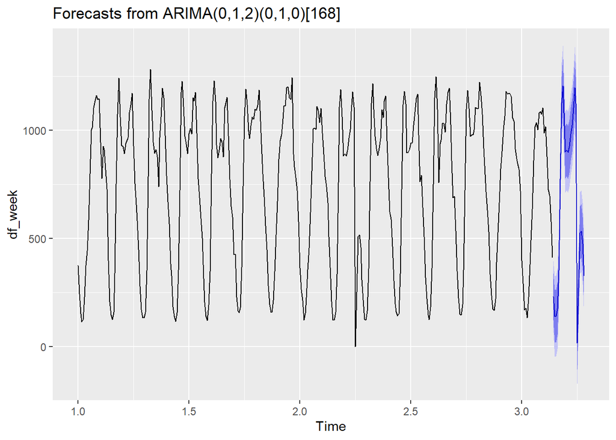

```r
#plot the result
autoplot(July1_predicted_week)
```

## Question 6:

Build a hour of the day seasonal 𝐴𝑅𝐼𝑀𝐴(𝑝, 𝑑, 𝑞)(𝑃,𝑄,𝐷)𝑠model using the training dataset and R auto.arima() function.

```r
df_hour = ts(df_train,frequency=24)
df_hourfit = auto.arima(df_hour,seasonal = TRUE, trace = TRUE)
```

```
##
##  Fitting models using approximations to speed things up...
##
##  ARIMA(2,0,2)(1,1,1)[24] with drift         : Inf
##  ARIMA(0,0,0)(0,1,0)[24] with drift         : 4167.373
##  ARIMA(1,0,0)(1,1,0)[24] with drift         : 3885.829
##  ARIMA(0,0,1)(0,1,1)[24] with drift         : 3970.283
##  ARIMA(0,0,0)(0,1,0)[24]                    : 4165.352
##  ARIMA(1,0,0)(0,1,0)[24] with drift         : 3930.078
##  ARIMA(1,0,0)(2,1,0)[24] with drift         : 3871.264
##  ARIMA(1,0,0)(2,1,1)[24] with drift         : Inf
##  ARIMA(1,0,0)(1,1,1)[24] with drift         : Inf
##  ARIMA(0,0,0)(2,1,0)[24] with drift         : 4104.352
##  ARIMA(2,0,0)(2,1,0)[24] with drift         : 3856.032
##  ARIMA(2,0,0)(1,1,0)[24] with drift         : 3879.512
##  ARIMA(2,0,0)(2,1,1)[24] with drift         : Inf
##  ARIMA(2,0,0)(1,1,1)[24] with drift         : Inf
##  ARIMA(3,0,0)(2,1,0)[24] with drift         : 3857.821
##  ARIMA(2,0,1)(2,1,0)[24] with drift         : 3855.049
##  ARIMA(2,0,1)(1,1,0)[24] with drift         : 3874.88
##  ARIMA(2,0,1)(2,1,1)[24] with drift         : Inf
##  ARIMA(2,0,1)(1,1,1)[24] with drift         : Inf
##  ARIMA(1,0,1)(2,1,0)[24] with drift         : 3858.32
##  ARIMA(3,0,1)(2,1,0)[24] with drift         : 3855.431
##  ARIMA(2,0,2)(2,1,0)[24] with drift         : 3853.66
##  ARIMA(2,0,2)(1,1,0)[24] with drift         : 3875.277
##  ARIMA(2,0,2)(2,1,1)[24] with drift         : Inf
##  ARIMA(1,0,2)(2,1,0)[24] with drift         : 3858.082
##  ARIMA(3,0,2)(2,1,0)[24] with drift         : 3857.454
##  ARIMA(2,0,3)(2,1,0)[24] with drift         : 3861.032
##  ARIMA(1,0,3)(2,1,0)[24] with drift         : 3858.354
##  ARIMA(3,0,3)(2,1,0)[24] with drift         : Inf
##  ARIMA(2,0,2)(2,1,0)[24]                    : 3851.563
##  ARIMA(2,0,2)(1,1,0)[24]                    : 3873.256
##  ARIMA(2,0,2)(2,1,1)[24]                    : Inf
##  ARIMA(2,0,2)(1,1,1)[24]                    : Inf
##  ARIMA(1,0,2)(2,1,0)[24]                    : 3855.997
##  ARIMA(2,0,1)(2,1,0)[24]                    : 3852.963
##  ARIMA(3,0,2)(2,1,0)[24]                    : 3855.344
##  ARIMA(2,0,3)(2,1,0)[24]                    : 3858.921
##  ARIMA(1,0,1)(2,1,0)[24]                    : 3856.247
##  ARIMA(1,0,3)(2,1,0)[24]                    : 3856.256
##  ARIMA(3,0,1)(2,1,0)[24]                    : 3853.334
##  ARIMA(3,0,3)(2,1,0)[24]                    : Inf
##
##  Now re-fitting the best model(s) without approximations...
##
##  ARIMA(2,0,2)(2,1,0)[24]                    : 4104.903
##
##  Best model: ARIMA(2,0,2)(2,1,0)[24]
```

```r
df_hourfit
```

```
## Series: df_hour
## ARIMA(2,0,2)(2,1,0)[24]
##
## Coefficients:
##          ar1      ar2      ma1      ma2     sar1     sar2
##       1.5965  -0.6895  -0.6772  -0.1650  -0.4151  -0.3254
## s.e.  0.0639   0.0521   0.0815   0.0694   0.0565   0.0535
##
## sigma^2 = 11243:  log likelihood = -2045.28
## AIC=4104.56   AICc=4104.9   BIC=4131.28
```

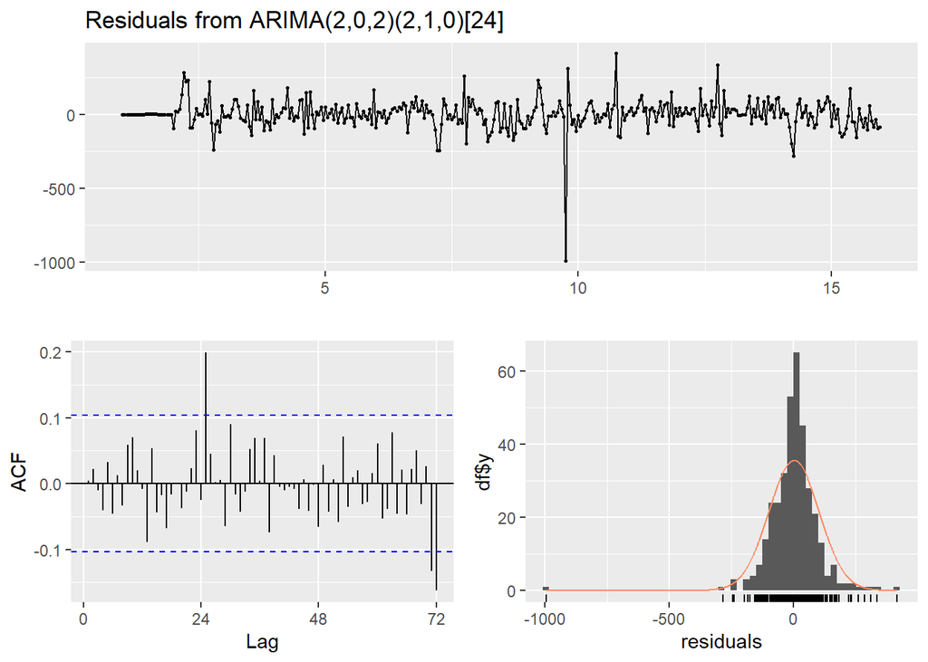

```
##
##  Ljung-Box test
##
## data:  Residuals from ARIMA(2,0,2)(2,1,0)[24]
## Q* = 49.401, df = 42, p-value = 0.2015
##
## Model df: 6.   Total lags used: 48
```

```r
checkresiduals(df_hourfit)
```

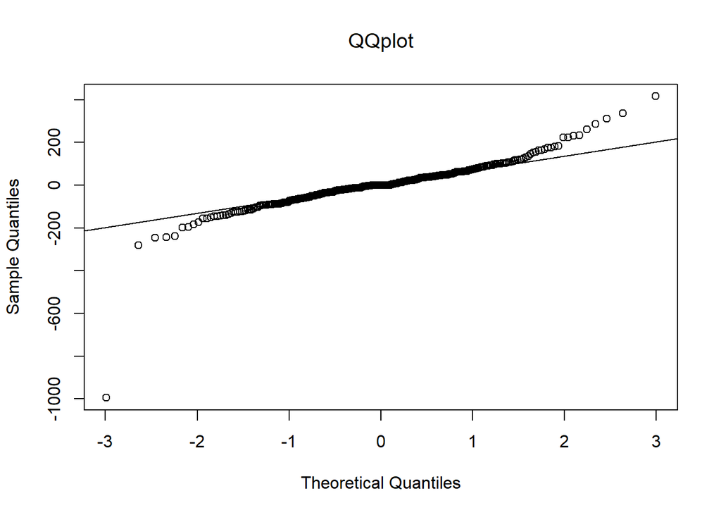

```r
qqnorm(df_hourfit$residuals,main=expression(QQplot))
qqline(df_hourfit$residuals)
```

The hourly model has a AICc = 4104.9

## Question 7:

Use the 𝐴𝑅𝐼𝑀𝐴(𝑝, 𝑑, 𝑞)(𝑃, 𝑄, 𝐷)𝑠 model from Question 6 to forecast for July 1st (which is a Monday). Plot your result.

```r
July1_predicted_hour <- forecast((df_hourfit), h = 24)
July1_predicted_hour
```

```
##          Point Forecast     Lo 80     Hi 80      Lo 95     Hi 95
## 16.00000       227.8330  91.94818  363.7179   20.01507  435.6510
## 16.04167       200.6664  16.08989  385.2429  -81.61901  482.9518
## 16.08333       171.3102 -31.19712  373.8175 -138.39801  481.0184
## 16.12500       225.7283  17.86634  433.5902  -92.16912  543.6257
## 16.16667       275.6225  67.03403  484.2109  -43.38603  594.6310
## 16.20833       474.0490 265.41085  682.6871  154.96450  793.1334
## 16.25000       694.6896 485.16432  904.2148  374.24836 1015.1308
## 16.29167       794.1640 582.82731 1005.5007  470.95243 1117.3756
## 16.33333       854.5382 640.96885 1068.1076  527.91205 1181.1644
## 16.37500       938.8870 723.20188 1154.5720  609.02511 1268.7488
## 16.41667      1030.5067 813.15384 1247.8596  698.09417 1362.9193
## 16.45833      1036.2899 817.81366 1254.7661  702.15935 1370.4204
## 16.50000      1025.3258 806.20510 1244.4466  690.20958 1360.4421
## 16.54167      1096.9451 877.51978 1316.3703  761.36306 1432.5271
## 16.58333      1095.5723 876.03954 1315.1051  759.82591 1431.3187
## 16.62500      1083.8175 864.26428 1303.3708  748.03980 1419.5953
## 16.66667      1139.2999 919.74664 1358.8532  803.52216 1475.0777
## 16.70833      1041.9611 822.39888 1261.5234  706.16964 1377.7526
## 16.75000      1030.5066 810.92097 1250.0923  694.67935 1366.3339
## 16.79167       888.2043 668.58663 1107.8219  552.32807 1224.0805
## 16.83333       755.7738 536.12371  975.4239  419.84798 1091.6996
## 16.87500       712.9892 493.31221  932.6663  377.02221 1048.9563
## 16.91667       615.5691 395.87305  835.2652  279.57297  951.5653
## 16.95833       477.2765 257.56894  696.9840  141.26281  813.2901
```

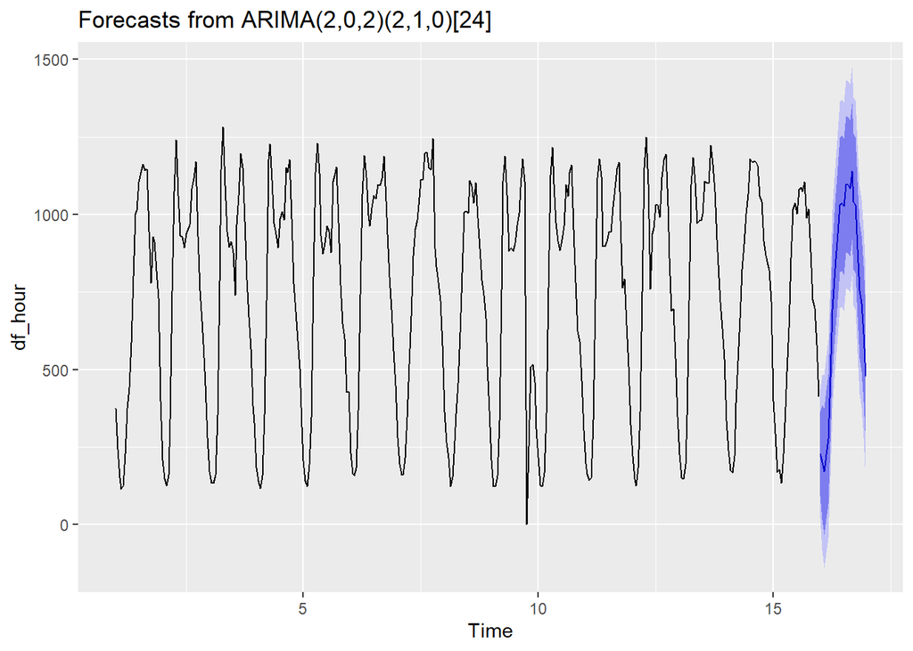

```r
autoplot(July1_predicted_hour)
```

## Question 8:

Compare the forecast of the models from Questions 5 and 7 for July 1 8:00, 9:00, 17:00 and 18:00, which model is better (Questions 4 or 6)?

```r
weekly_model_error = sum((df_test[c(8,9,17,18)] - July1_predicted_week$mean[c(8,9,17,18)])^2)
hourly_model_error = sum((df_test[c(8,9,17,18)] - July1_predicted_hour$mean[c(8,9,17,18)])^2)

cat("Weekly Model Error: ", weekly_model_error, "\n")
```

```
## Weekly Model Error:  4604.173
```

```r
cat("Hourly Model Error: ", hourly_model_error, "\n")
```

```
## Hourly Model Error:  265420.8
```

From above result, we can see that the weekly model in Q4 has a smaller sum of errors than the hourly model in Q6. Therefore, the model in Question 4 is better.